DS 6030 | Fall 2024 | University of Virginia

# Homework #4: Trees and Random Forest

Author

Courtney Hodge

Published

September 30, 2024

This is an **independent assignment**. Do not discuss or work with classmates.

# Required R packages and Directories

```r
data_dir = 'https://mdporter.github.io/teaching/data/' # data directory
library(tidyverse)    # functions for data manipulation
library(ranger)       # fast random forest implementation
library(modeldata)    # for the ames housing data
```

# Problem 1: Tree splitting metrics for classification

Consider the Gini index, classification error, and entropy impurity measures in a simple classification setting with two classes.

Create a single plot that displays each of these quantities as a function of $p_m$, the estimated probability of an observation in node $m$ being from class 1. The x-axis should display $p_m$, ranging from 0 to 1, and the y-axis should display the value of the Gini index, classification error, and entropy.

**Solution**

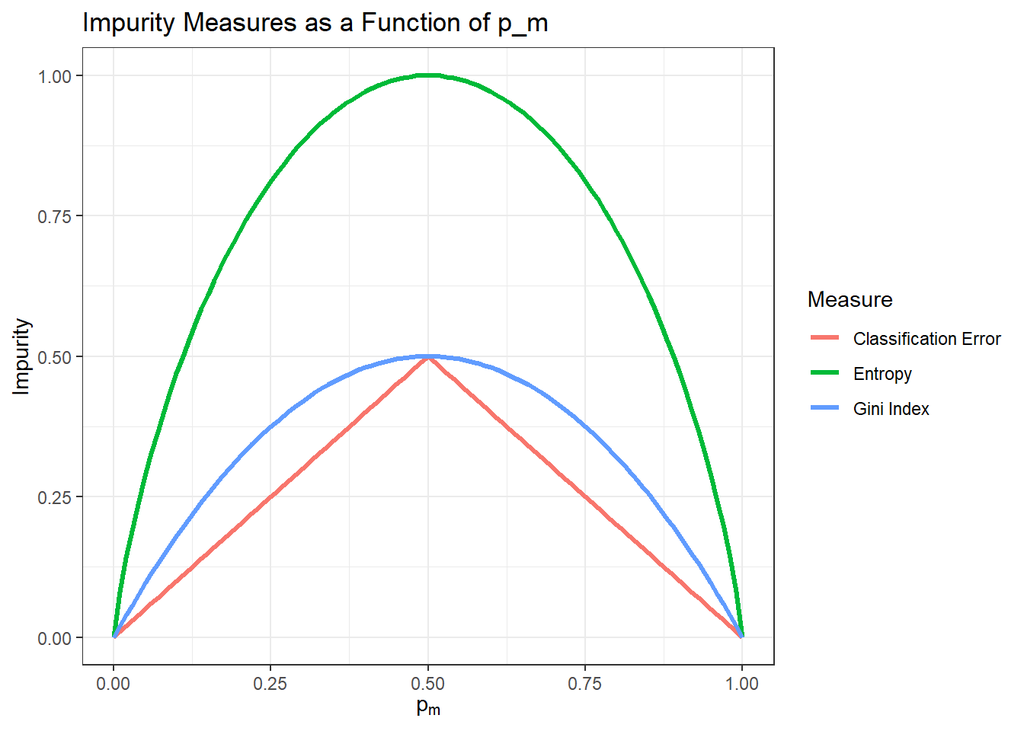

```r
# Load ggplot2 library
library(ggplot2)

#Define p_m
p_m <- seq(0, 1, by = 0.01)

#Calculate the impurity measures

# Gini index
gini <- 2 * p_m * (1 - p_m)

# Classification Error
class_error <- 1 - pmax(p_m, 1 - p_m)

# Entropy (handle 0*log(0) cases by replacing NaN with 0)
entropy <- -p_m * log2(p_m) - (1 - p_m) * log2(1 - p_m)
entropy[is.nan(entropy)] <- 0  # Set NaN values to 0 (for p_m = 0 or 1)

#Create a data frame for ggplot
df <- data.frame(
  p_m = rep(p_m, 3),
  Impurity = c(gini, class_error, entropy),
  Measure = factor(rep(c("Gini Index", "Classification Error", "Entropy"), each = length(p_m)))
)

#plot
ggplot(df, aes(x = p_m, y = Impurity, color = Measure)) +
  geom_line(size = 1.2) +
  labs(
    title = "Impurity Measures as a Function of p_m",
    x = expression(p[m]),
    y = "Impurity"
  )
```

# Problem 2: Combining bootstrap estimates

Suppose we produce ten bootstrapped samples from a data set containing red and green classes. We then apply a classification tree to each bootstrapped sample and, for a specific value of $X$, produce the following 10 estimates of $\Pr(\text{Class is Red} \mid X=x)$: $\{0.2, 0.25, 0.3, 0.4, 0.4, 0.45, 0.7, 0.85, 0.9, 0.9\}$.

## a. Majority Vote

ISLR 8.2 describes the *majority vote* approach for making a hard classification from a set of bagged classifiers. What is the final classification for this example using majority voting?

**Solution**

> Using the majority vote, we can classify each of the 10 bootstrapped results as “Red” or “Green” using a 0.5 threshold (over 0.5, likely “Red”, under 0.5, likely “Green”) for the probability estimate. So we can say:

$Pr(\text{Class is Red}| X = x) \geqq 0.5, \text{the class is "Red"}$

$Pr(\text{Class is Red}| X = x) \lt 0.5, \text{the class is "Green"}$

> The majority vote rule says that the class with the most votes becomes the final classification. Based on the given probabilities:

Probabilities less than 0.5: {0.2,0.25,0.3,0.4,0.4,0.45} — classify as “Green”.

> and

Probabilities greater than or equal to 0.5: {0.7,0.85,0.9,0.9} — classify as “Red”.

> **So total “Green”: 6 votes and total “Red”: 4 votes. This means the FINAL CLASSIFICATION is “Green”**

## b. Average Probability

An alternative is to base the final classification on the average probability. What is the final classification for this example using average probability?

**Solution**

> Using the average probability approach, we can find the final classification by calculating the average probability and classify based on this average using the same threshold of 0.5. We can now say:

If the avg prob is $\geqq$ to 0.5, classify as “Red”

If the avg prob is $\lt$ 0.5, classify as “Green”

> Based on the given probabilities, we can calculate the avg prob as:

```r
avg_prob <- mean(p_red)
avg_prob
```

```
[1] 0.535
```

> **Since the average probability 0.535 > 0.5, the FINAL CLASSFICATION is “Red”**

# Problem 3: Random Forest Tuning

Random forest has several tuning parameters that you will explore in this problem. We will use the `ames` housing data from the `modeldata` R package.

There are several R packages for Random Forest. The `ranger::ranger()` function is much faster than `randomForest::randomForest()` so we will use this one.

## a. Random forest (`ranger`) tuning parameters

List all of the random forest tuning parameters in the `ranger::ranger()` function. You don’t need to list the parameters related to computation, special models (e.g., survival, maxstat), or anything that won’t impact the predictive performance.

Indicate the tuning parameters you think will be most important to optimize?

**Solution**

```r
library("modeldata")
library("ranger")
head(ames)
```

```
# A tibble: 6 × 74
  MS_SubClass             MS_Zoning Lot_Frontage Lot_Area Street Alley Lot_Shape
  <fct>                   <fct>            <dbl>    <int> <fct>  <fct> <fct>
1 One_Story_1946_and_New… Resident…          141    31770 Pave   No_A… Slightly…
2 One_Story_1946_and_New… Resident…           80    11622 Pave   No_A… Regular
3 One_Story_1946_and_New… Resident…           81    14267 Pave   No_A… Slightly…
4 One_Story_1946_and_New… Resident…           93    11160 Pave   No_A… Regular
5 Two_Story_1946_and_New… Resident…           74    13830 Pave   No_A… Slightly…
6 Two_Story_1946_and_New… Resident…           78     9978 Pave   No_A… Slightly…
# ℹ 67 more variables: Land_Contour <fct>, Utilities <fct>, Lot_Config <fct>,
#   Land_Slope <fct>, Neighborhood <fct>, Condition_1 <fct>, Condition_2 <fct>,
#   Bldg_Type <fct>, House_Style <fct>, Overall_Cond <fct>, Year_Built <int>,
#   Year_Remod_Add <int>, Roof_Style <fct>, Roof_Matl <fct>,
#   Exterior_1st <fct>, Exterior_2nd <fct>, Mas_Vnr_Type <fct>,
#   Mas_Vnr_Area <dbl>, Exter_Cond <fct>, Foundation <fct>, Bsmt_Cond <fct>,
#   Bsmt_Exposure <fct>, BsmtFin_Type_1 <fct>, BsmtFin_SF_1 <dbl>, …
```

> Below is a list of all the relevant random forest tuning parameters in the ranger function that impact the predictive performance. After calling ?ranger in the console window, the non-important tuning parameters are filtered out and we’re left with these arguments to answer part a:

**Tuning Parameters for Predictive Performance in ranger()**

- num.trees - Number of trees.
- mtry - Number of variables to possibly split at in each node. Default is the (rounded down) square root of the number variables. Alternatively, a single argument function returning an integer, given the number of independent variables.
- min.node.size - Minimal node size to split at. Default 1 for classification, 5 for regression, 3 for survival, and 10 for probability.
- sample.fraction - Fraction of observations to sample. Default is 1 for sampling with replacement and 0.632 for sampling without replacement. For classification, this can be a vector of class-specific values.
- importance - Variable importance mode, one of ‘none’, ‘impurity’, ‘impurity_corrected’, ‘permutation’. The ‘impurity’ measure is the Gini index for classification, the variance of the responses for regression and the sum of test statistics (see splitrule) for survival.
- splitrule - Splitting rule. For classification and probability estimation “gini”, “extratrees” or “hellinger” with default “gini”. For regression “variance”, “extratrees”, “maxstat” or “beta” with default “variance”. For survival “logrank”, “extratrees”, “C” or “maxstat” with default “logrank”.

**Tuning Parameters Most Important to Optimize**

- mtry
- min.node.size
- num.trees
- sample.fraction

## b. Implement Random Forest

Use a random forest model to predict the sales price, `Sale_Price`. Use the default parameters and report the 10-fold cross-validation RMSE (square root of mean squared error).

**Solution**

```r
library("caret")
#remove missing rows
ames <- na.omit(ames)

#get target variable
target <- ames$Sale_Price

#separate the features (X) and the target variable (y)
X <- ames[, !(names(ames) %in% target)]
y <- ames$Sale_Price
```

> Set up 10-fold CV

```r
set.seed(123)

#10-fold cross-validation
cv_control <- trainControl(method = 'cv', number = 10)

#train the random forest model w/ ranger and a 10-fold cross-validation

rf_model <- train(Sale_Price ~., data = ames, method = "ranger", trControl = cv_control, metric = "RMSE")
```

```r
rf_model
```

```
Random Forest

2930 samples
  73 predictor

No pre-processing
Resampling: Cross-Validated (10 fold)
Summary of sample sizes: 2637, 2637, 2637, 2636, 2637, 2638, ...
Resampling results across tuning parameters:

  mtry  splitrule   RMSE   Rsquared  MAE
    2   variance    48016  0.793     31411
    2   extratrees  52972  0.737     35755
  139   variance    27457  0.884     16422
  139   extratrees  27628  0.886     16365
  276   variance    28319  0.875     16777
  276   extratrees  27318  0.887     16224

Tuning parameter 'min.node.size' was held constant at a value of 5
RMSE was used to select the optimal model using the smallest value.
The final values used for the model were mtry = 276, splitrule = extratrees
 and min.node.size = 5.
```

> Based on the result, we can see the best 10-fold CV RMSE for this random forest was found at the following combination:
- mtry = 276
- splitrule = extratrees
- min.node.size = 5

> **This model provided the best RMSE of 27318.16**

## c. Random Forest Tuning

Now we will vary the tuning parameters of `mtry` and `min.bucket` to see what effect they have on performance.

- Use a range of reasonable `mtry` and `min.bucket` values.
  - The valid `mtry` values are $\{1,2, \ldots, p\}$ where $p$ is the number of predictor variables. However the default value of `mtry = sqrt(p) =` 8 is usually close to optimal, so you may want to focus your search around those values.
  - The default `min.bucket=1` will grow deep trees. This will usually work best if there are enough trees. But try some values larger and see how it impacts predictive performance.
  - Set `num.trees=1000`, which is larger than the default of 500.
- Use 5 times repeated out-of-bag (OOB) to assess performance. That is, run random forest 5 times for each tuning set, calculate the OOB MSE each time and use the average for the MSE associated with the tuning parameters.
- Use a single plot to show the average MSE as a function of `mtry` and `min.bucket`.
- Report the best tuning parameter combination.
- Note: random forest is a stochastic model; it will be different every time it runs due to the bootstrap sampling and random selection of features to consider for splitting. Set the random seed to control the uncertainty associated with the stochasticity.
- Hint: If you use the `ranger` package, the `prediction.error` element in the output is the OOB MSE.

**Solution**

```r
set.seed(123)

#set number of predictors (p) and default mtry values
p <- ncol(ames) - 1 #subtract 1 for terget variable (Sale_Price)

default_mtry <- floor(sqrt(p)) #default mtry = sqrt(p)

#define a range of mtry and min.bucket values
mtry_values <- seq(max(1, default_mtry - 2), default_mtry + 2, by = 1)

#start w/ default and try larger values
min_bucket_values <- c(1, 5, 10, 20)

#number of trees
num_trees <- 1000

#function to train a random forest model and return OOB MSE
rf_oob_mse <- function(mtry, min_bucket, num_repeats = 5) {
  oob_mse_values <- numeric(num_repeats)
  for (i in 1:num_repeats) {
    model <- ranger(
      Sale_Price ~ .,
      data = ames,
      mtry = mtry,
      min.node.size = min_bucket,
      num.trees = num_trees,
      oob.error = TRUE
    )
    oob_mse_values[i] <- model$prediction.error
  }
  return(mean(oob_mse_values))  # Return the average OOB MSE across repeats
}

# Create a data frame to store the results
results <- expand.grid(mtry = mtry_values, min_bucket = min_bucket_values) %>%
  mutate(OOB_MSE = purrr::map2_dbl(mtry, min_bucket, rf_oob_mse))
```

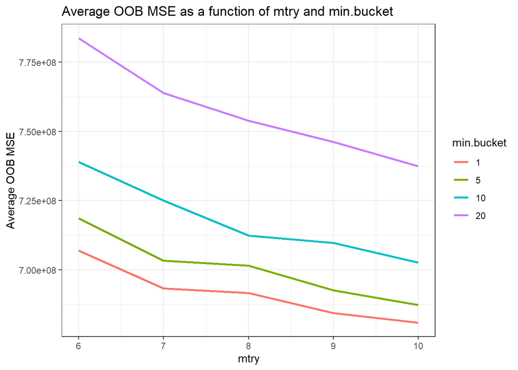

```r
# Plot the average OOB MSE as a function of mtry and min.bucket
ggplot(results, aes(x = mtry, y = OOB_MSE, color = factor(min_bucket))) +
  geom_line(size = 1) +
  labs(
    title = "Average OOB MSE as a function of mtry and min.bucket",
    x = "mtry",
    y = "Average OOB MSE",
    color = "min.bucket"
  )
```

```r
# Find the best tuning parameter combination
best_params <- results %>%
  arrange(OOB_MSE) %>%
  slice(1)

best_params
```

```
  mtry min_bucket  OOB_MSE
1   10          1 6.81e+08
```